# Chapter 6: Analysis of longidutinal data

In this chapter I am analyzing two longitudinal studies. First one, `RATS`, is investigating weight differences between 3 distinct groups over time. Second, `BPRS`, is comparing 2 different treatments effect on psychiatric evaluation outcome of subjects.

Data wrangling R script for this is exercise is found from here:  
https://github.com/neabister/IODS-project/blob/master/data/meet_and_repeat.R

## Import libraries, read and visualize data

First datasets are read from wrangling file and variables for subject/ID and treatment/group are converted back to factors for the analysis.

```r
library(ggplot2)
library(dplyr)

rats_data <- read.csv('data/RATSL.csv')
bprs_data <- read.csv('data/BPRSL.csv')

rats_data$ID <- factor(rats_data$ID)
rats_data$Group <- factor(rats_data$Group)
bprs_data$subject <- factor(bprs_data$subject)
bprs_data$treatment <- factor(bprs_data$treatment)

glimpse(rats_data)
```

```
## Observations: 176
## Variables: 4
## $ ID     <fct> 1, 2, 3, 4, 5, 6, 7, 8, 9, 10, 11, 12, 13, 14, 15, 16, 1, 2,...
## $ Group  <fct> 1, 1, 1, 1, 1, 1, 1, 1, 2, 2, 2, 2, 3, 3, 3, 3, 1, 1, 1, 1, ...
## $ weight <int> 240, 225, 245, 260, 255, 260, 275, 245, 410, 405, 445, 555, ...
## $ day    <int> 1, 1, 1, 1, 1, 1, 1, 1, 1, 1, 1, 1, 1, 1, 1, 1, 8, 8, 8, 8, ...
```

```r
glimpse(bprs_data)
```

```
## Observations: 360
## Variables: 4
## $ treatment <fct> 1, 1, 1, 1, 1, 1, 1, 1, 1, 1, 1, 1, 1, 1, 1, 1, 1, 1, 1, ...
## $ subject   <fct> 1, 2, 3, 4, 5, 6, 7, 8, 9, 10, 11, 12, 13, 14, 15, 16, 17...
## $ bprs      <int> 42, 58, 54, 55, 72, 48, 71, 30, 41, 57, 30, 55, 36, 38, 6...
## $ week      <int> 0, 0, 0, 0, 0, 0, 0, 0, 0, 0, 0, 0, 0, 0, 0, 0, 0, 0, 0, ...
```

## RATS - Graphical display and Summary Measure Analysis

### Lineplot of the longitudinal values separated for all 3 groups

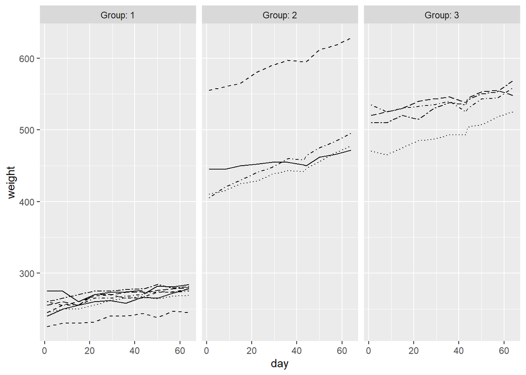

```r
ggplot(rats_data, aes(x = day, y = weight, linetype = ID)) + geom_line() + scale_linetype_manual(values = rep(1:10, times=4)) + facet_grid(. ~ Group, labeller = label_both) + theme(legend.position = "none") + scale_y_continuous(limits = c(min(rats_data$weight), max(rats_data$weight)))
```

Above graphs show that all Groups have one rat that is different from others, possibly outliers. This is clearest in Group 2. It can be seen also that overall Group 1 weights are much lower than Group 2 and 3 from start until the end. Furthermore, it can be seen that the weights are increasing in time in all groups but perhaps there could be diferences in the rate of increase (slope)…

### Same from standardized data

```r
n <- rats_data$day %>% unique() %>% length()

rats_data <- rats_data %>% group_by(day) %>% mutate(stdardized = (weight - mean(weight))/sd(weight)) %>% ungroup()

# Summary data with mean and standard error of bprs by treatment and week
rats_data_summary <- rats_data %>%
  group_by(Group, day) %>%
  summarise(mean = mean(stdardized), se = sd(stdardized)/sqrt(n) ) %>%
  ungroup()

glimpse(rats_data_summary)
```

```
## Observations: 33
## Variables: 4
## $ Group <fct> 1, 1, 1, 1, 1, 1, 1, 1, 1, 1, 1, 2, 2, 2, 2, 2, 2, 2, 2, 2, 2...
## $ day   <int> 1, 8, 15, 22, 29, 36, 43, 44, 50, 57, 64, 1, 8, 15, 22, 29, 3...
## $ mean  <dbl> -0.9166792, -0.9213162, -0.9270291, -0.9235906, -0.9253853, -...
## $ se    <dbl> 0.03648416, 0.03188681, 0.02715453, 0.03226803, 0.02585809, 0...
```

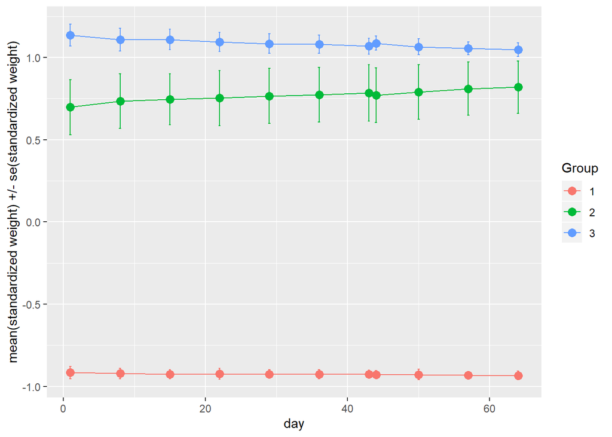

```r
ggplot(rats_data_summary, aes(x = day, y = mean, col=Group)) +
  geom_line() +
  geom_point(size=3) +
  geom_errorbar(aes(ymin = mean - se, ymax = mean + se), width=0.3) +
  scale_y_continuous(name = "mean(standardized weight) +/- se(standardized weight)")
```

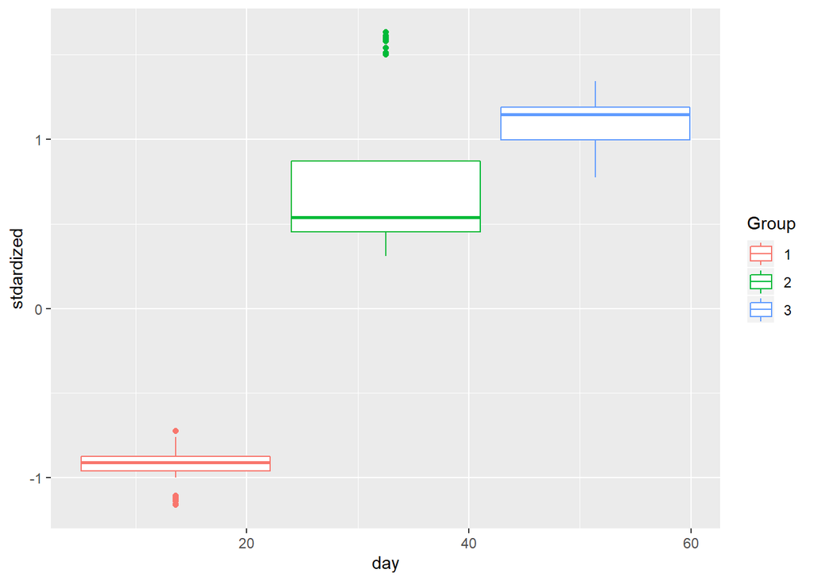

```r
ggplot(rats_data, aes(x = day, y = stdardized, col = Group)) +
geom_boxplot() +  scale_y_continuous(limits = c(min(rats_data$stdardized), max(rats_data$stdardized)))
```

### Barplots side by side to evaluate outliers

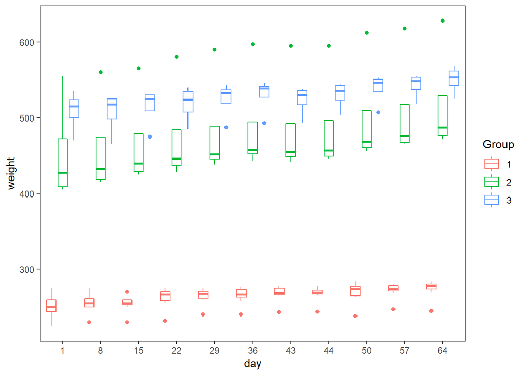

```r
p1 <- ggplot(rats_data, aes(x = factor(day), y = weight, col = Group))
p2 <- p1 + geom_boxplot(position = position_dodge(width = 0.9))
p3 <- p2 + theme_bw() + theme(panel.grid.major = element_blank(), panel.grid.minor = element_blank())
p4 <- p3 + scale_x_discrete(name = "day")

p4
```

### Outlier removal

From previous tab bar plot it can be seen that all three groups have one outlier value present in almost all timepoint, if not in all. Next, I will try and remove these outliers.

```r
#Filter each group to their own df

group_1 <- rats_data %>% filter(Group == 1)
group_2 <- rats_data %>% filter(Group == 2)
group_3 <- rats_data %>% filter(Group == 3)

n_1 <- group_1$ID %>% unique() %>% length()
n_2 <- group_2$ID %>% unique() %>% length()
n_3 <- group_3$ID %>% unique() %>% length()

n_1
```

```
## [1] 8
```

```r
n_2
```

```
## [1] 4
```

```r
n_3
```

```
## [1] 4
```

```r
#Print summaries to see lowest and highest values for each group to decide the limits for outlier, trying with 1st or 3rd quartile for lowest/upper limit
summary(group_1)
```

```
##        ID     Group      weight           day          stdardized
##  1      :11   1:88   Min.   :225.0   Min.   : 1.00   Min.   :-1.1618
##  2      :11   2: 0   1st Qu.:255.0   1st Qu.:15.00   1st Qu.:-0.9593
##  3      :11   3: 0   Median :267.0   Median :36.00   Median :-0.9104
##  4      :11          Mean   :263.7   Mean   :33.55   Mean   :-0.9265
##  5      :11          3rd Qu.:274.0   3rd Qu.:50.00   3rd Qu.:-0.8753
##  6      :11          Max.   :284.0   Max.   :64.00   Max.   :-0.7229
##  (Other):22
```

```r
summary(group_2)
```

```
##        ID     Group      weight           day          stdardized
##  9      :11   1: 0   Min.   :405.0   Min.   : 1.00   Min.   :0.3105
##  10     :11   2:44   1st Qu.:444.5   1st Qu.:15.00   1st Qu.:0.4543
##  11     :11   3: 0   Median :457.0   Median :36.00   Median :0.5405
##  12     :11          Mean   :484.7   Mean   :33.55   Mean   :0.7680
##  1      : 0          3rd Qu.:510.8   3rd Qu.:50.00   3rd Qu.:0.8698
##  2      : 0          Max.   :628.0   Max.   :64.00   Max.   :1.6330
##  (Other): 0
```

```r
summary(group_3)
```

```
##        ID     Group      weight           day          stdardized
##  13     :11   1: 0   Min.   :465.0   Min.   : 1.00   Min.   :0.7749
##  14     :11   2: 0   1st Qu.:513.8   1st Qu.:15.00   1st Qu.:0.9954
##  15     :11   3:44   Median :530.0   Median :36.00   Median :1.1461
##  16     :11          Mean   :525.8   Mean   :33.55   Mean   :1.0850
##  1      : 0          3rd Qu.:543.0   3rd Qu.:50.00   3rd Qu.:1.1893
##  2      : 0          Max.   :569.0   Max.   :64.00   Max.   :1.3440
##  (Other): 0
```

```r
#Remove outliers by filtering
group_1 <- group_1 %>% filter(weight > 255)
group_2 <- group_2 %>% filter(weight < 511)
group_3 <- group_3 %>% filter(weight > 513)

n_1 <- group_1$ID %>% unique() %>% length()
n_2 <- group_2$ID %>% unique() %>% length()
n_3 <- group_3$ID %>% unique() %>% length()

n_1
```

```
## [1] 7
```

```r
n_2
```

```
## [1] 3
```

```r
n_3
```

```
## [1] 4
```

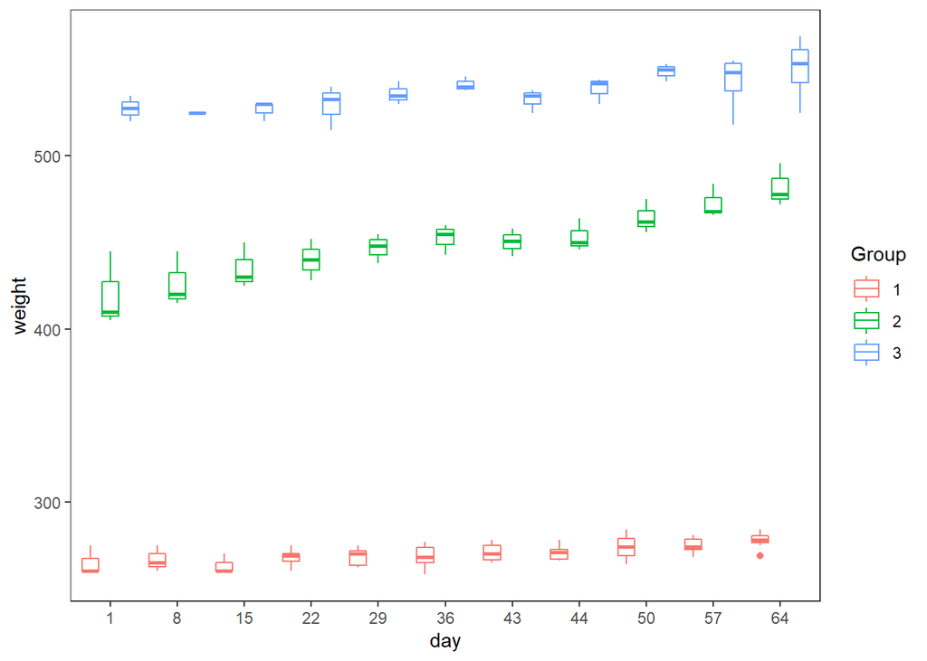

```r
#Bind back together
no_outliers <- rbind(group_1, group_2, group_3)

#Check how the plot looks now
p1 <- ggplot(no_outliers, aes(x = factor(day), y = weight, col = Group))
p2 <- p1 + geom_boxplot(position = position_dodge(width = 0.9))
p3 <- p2 + theme_bw() + theme(panel.grid.major = element_blank(), panel.grid.minor = element_blank())
p4 <- p3 + scale_x_discrete(name = "day")

p4
```

After trying to remove outliers with above method, it can be seen that we get rid of outliers in Group 1 but for other two groups it does not work. For Group 3, the 1st Quartile limit was not enough to remove the outlier and from Group 2 one sample was removed with 3rd Quartile limit. Since in Groups 2 and 3 the n number was already low (4) in the beginning, I suggest that detecting real outliers is not accurate enough to confidently remove any outliers from these groups. So I will continue by removing only one rat from Group 1, simply using filter on the original dataframe:

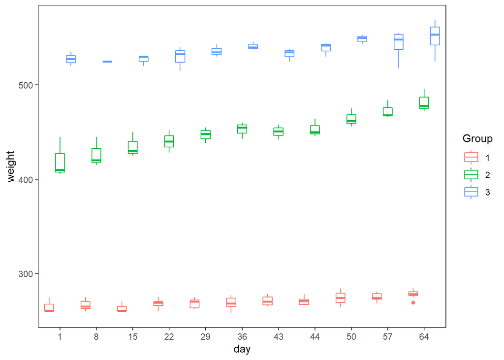

```r
no_outliers_rats <- rats_data %>% filter(weight >255)

p1 <- ggplot(no_outliers, aes(x = factor(day), y = weight, col = Group))
p2 <- p1 + geom_boxplot(position = position_dodge(width = 0.9))
p3 <- p2 + theme_bw() + theme(panel.grid.major = element_blank(), panel.grid.minor = element_blank())
p4 <- p3 + scale_x_discrete(name = "day")

p4
```

### lm fitting and Anova - NOT FINISHED

```r
#Filter out baseline
no_outliers_ratsS <- no_outliers_rats %>%
  filter(day > 1) %>%
  group_by(Group, ID) %>%
  summarise(mean=mean(weight)) %>%
  ungroup()
glimpse(no_outliers_ratsS)
```

```
## Observations: 15
## Variables: 3
## $ Group <fct> 1, 1, 1, 1, 1, 1, 1, 2, 2, 2, 2, 3, 3, 3, 3
## $ ID    <fct> 1, 3, 4, 5, 6, 7, 8, 9, 10, 11, 12, 13, 14, 15, 16
## $ mean  <dbl> 265.8750, 266.0000, 270.2500, 272.6667, 276.2000, 274.6000, 2...
```

```r
#Add baseline column to the filtered data
#baseline <- $week0
#BPRSL8S2 <- BPRSL8S %>%
 # mutate(baseline)


no_outliers_ratsS <- no_outliers_rats %>% group_by(Group, ID) %>% summarise( mean=mean(weight) ) %>% ungroup()
glimpse(no_outliers_ratsS)
```

```
## Observations: 15
## Variables: 3
## $ Group <fct> 1, 1, 1, 1, 1, 1, 1, 2, 2, 2, 2, 3, 3, 3, 3
## $ ID    <fct> 1, 3, 4, 5, 6, 7, 8, 9, 10, 11, 12, 13, 14, 15, 16
## $ mean  <dbl> 265.8750, 266.0000, 269.1111, 272.6667, 274.7273, 274.6364, 2...
```

```r
fit <- lm(mean ~ Group, data = no_outliers_ratsS)
summary(fit)
```

```
##
## Call:
## lm(formula = mean ~ Group, data = no_outliers_ratsS)
##
## Residuals:
##     Min      1Q  Median      3Q     Max
## -43.886 -17.142  -1.161   6.239 105.750
##
## Coefficients:
##             Estimate Std. Error t value Pr(>|t|)
## (Intercept)   270.27      14.05  19.242 2.19e-10 ***
## Group2        214.43      23.29   9.206 8.69e-07 ***
## Group3        255.52      23.29  10.970 1.31e-07 ***
## ---
## Signif. codes:  0 '***' 0.001 '**' 0.01 '*' 0.05 '.' 0.1 ' ' 1
##
## Residual standard error: 37.16 on 12 degrees of freedom
## Multiple R-squared:  0.9267, Adjusted R-squared:  0.9145
## F-statistic: 75.85 on 2 and 12 DF,  p-value: 1.552e-07
```

```r
anova(fit)
```

```
## Analysis of Variance Table
##
## Response: mean
##           Df Sum Sq Mean Sq F value    Pr(>F)
## Group      2 209511  104756  75.851 1.552e-07 ***
## Residuals 12  16573    1381
## ---
## Signif. codes:  0 '***' 0.001 '**' 0.01 '*' 0.05 '.' 0.1 ' ' 1
```

## BPRS data - Linear Mixed Effects Models for Normal Response Variables

First we will just plot the BPRS data, ignoring the repeated measures -caused dependencies and see how it looks to fit basic linear regression to later demonstrate the difference from methods for repeated measures data.

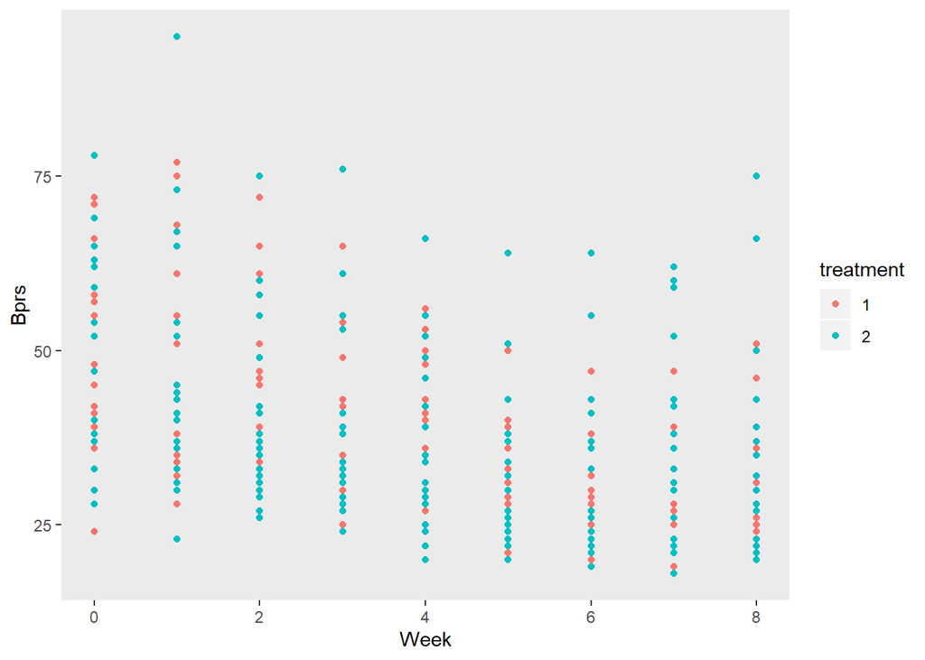

```r
p1 <- ggplot(bprs_data, aes(x = week, y = bprs, group = subject))
p2 <- p1 + geom_point(aes(color = treatment))
p3 <- p2 + scale_x_continuous(name = "Week")
p4 <- p3 + scale_y_continuous(name = "Bprs")
p5 <- p4 + theme(panel.grid.major = element_blank(), panel.grid.minor = element_blank())
p5
```

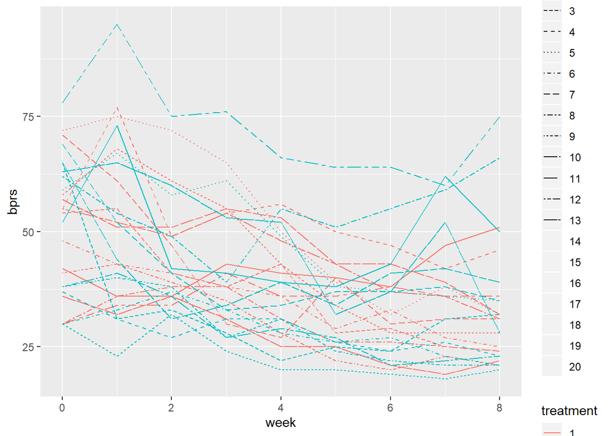

```r
ggplot(bprs_data, aes(x = week, y = bprs, linetype = subject)) + geom_line(aes(color = treatment))
```

By initial observation there is no clear pattern of values with certain treatment but the measurements are overlapping. There might be one outlier in week 1 time-point, since one value is much higher than others in any timepoint.

```r
bprs_lm <- lm(bprs ~ week + treatment, data = bprs_data)
summary(bprs_lm)
```

```
##
## Call:
## lm(formula = bprs ~ week + treatment, data = bprs_data)
##
## Residuals:
##     Min      1Q  Median      3Q     Max
## -22.454  -8.965  -3.196   7.002  50.244
##
## Coefficients:
##             Estimate Std. Error t value Pr(>|t|)
## (Intercept)  46.4539     1.3670  33.982   <2e-16 ***
## week         -2.2704     0.2524  -8.995   <2e-16 ***
## treatment2    0.5722     1.3034   0.439    0.661
## ---
## Signif. codes:  0 '***' 0.001 '**' 0.01 '*' 0.05 '.' 0.1 ' ' 1
##
## Residual standard error: 12.37 on 357 degrees of freedom
## Multiple R-squared:  0.1851, Adjusted R-squared:  0.1806
## F-statistic: 40.55 on 2 and 357 DF,  p-value: < 2.2e-16
```